# R Data files, plot and modeling

Biao Zhang

Sep 26, 2021

#### Visualization

1. (3 points) As you have seen in the in-class practice problems for visualization, the lines that connects all data points may be too wiggly (even when there is no cross lines) to reveal the overall pattern of y vs x relationship. When we do not know the true relationship, we do want to explore what it is through a scatter plot, ideally with as few assumptions on the form of this relationship (e.g., quadratic, monotone, and etc) as possible. One such weak assumption is smoothness. That is, the true relationship may be a smooth curve. During exploratory data analysis, it is a common practice to add smooth curves to the scatter plot to visually examine the pattern. R function lowess(x,y,f) generate such smooth relationship, where f is the smooth span parameter (proportion of the points that influence each data point). Larger f gives smoother curve (what is the smoothest curve? and what is the least smooth curve for given data points). Produce a scatter plot of `y` versus `x` (as in the lecture), and set the title and axes labels as you see fit. Then overlay on top four outputs of lowess with various smoothing span using lines(lowess(x,y,f=ff),....) where ff=1,2/3,1/3,0.01, respectively. Please fill "...." with appropriate options for lines() so that the four curves have different line type, color, and width. Is your output consistent with your understanding the meaning of f? In particular, can you describe what type of lines lowess returns when f=1 and f=0.01, respectively. Can you explain why in terms of the meaning of f, and our data (recall that 1/n > 0.01). Then add a legend to the top left corner of the plot using legend(). The legend should display the text "f=1", "f=2/3", "f=1/3", "f=0.01", with corresponding symbols (line type, width and color that you chose for your lines).

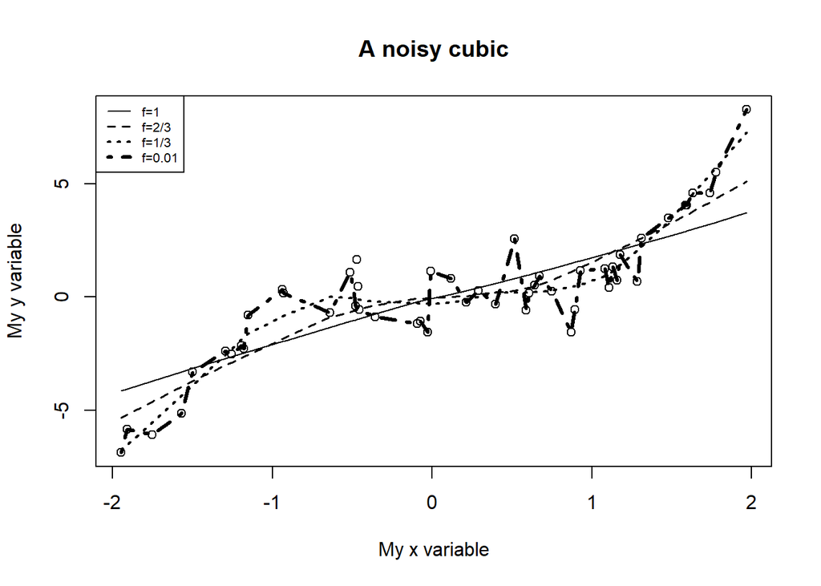

```r
n = 50
set.seed(0)
x = sort(runif(n, min=-2, max=2))
y = x^3 + rnorm(n)
plot(x, y, main = "A noisy cubic", xlab = "My x variable", ylab = "My y variable")
lines(lowess(x, y, f = 1), lty = 1)
lines(lowess(x, y, f = 2/3), lty = 2, lwd = 1.5)
lines(lowess(x, y, f = 1/3), lty = 3, lwd = 2)
lines(lowess(x, y, f = .01), lty = 4, lwd = 3)
legend("topleft", legend = c("f=1", "f=2/3", "f=1/3","f=0.01"), lty = c(1:4), lwd = c(1,1.5,2,3), cex = .65)
```

Comments: As f is the smoother span, when its value increases, the proportion of points influencing the smooth at each value increases. As 1/n = .02, if we set f = .01 < .02, each point influences the smooth of the plot, we could see the line goes through all points. If we set f = 1 >> .02, the line will not go through all points, it becomes much smoother. When f = 1, it gives the smoothest curve, almost a straight line. When f = .01, it gives the least smooth cuerve, a curve going through all points.

Comments: I do not use color to differentiate the type of lines. They are all black.

2. (4 points)Plot a round smiley face with size 10 "*" shaped brown eyes, and red mouth. Feel free to add any other interesting features as you like such as pointy teeth, nose, ears and etc, as long as they are not offensive to the others.

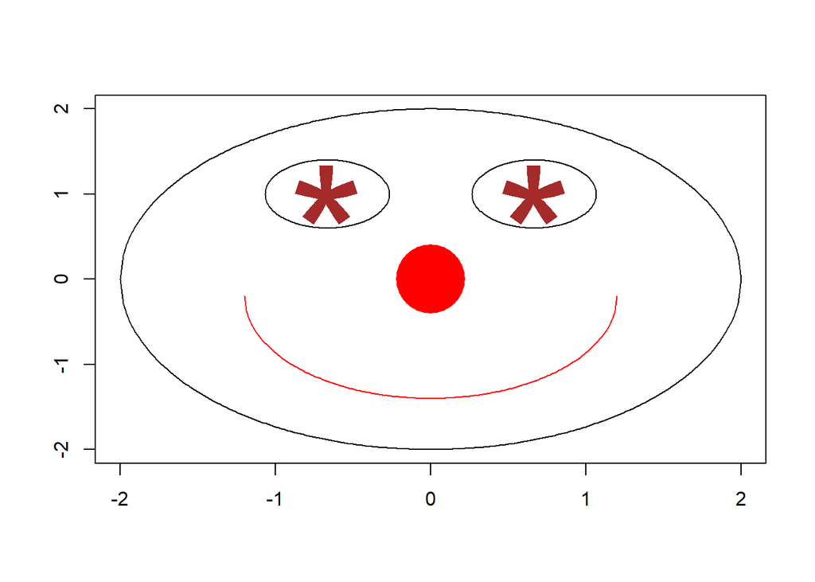

```r
x0 = (0:200-100)/100
y0 = sqrt(1-x0^2)
center.x=0
center.y=0
radius=2
plot(center.x,center.y,type='n',xlim = c(-radius,radius)+center.x,ylim = center.y+c(-radius,radius),xlab = '',ylab = '')
lines(center.x+x0*radius,center.y+y0*radius)
lines(center.x+x0*radius,center.y-y0*radius)
center.eyes.x = c(-1,1)*radius/3+center.x
center.eyes.y = radius*1/2+center.y
radius.eyes = radius*0.2
lines(center.eyes.x[1]+x0*radius.eyes,center.eyes.y+y0*radius.eyes)
lines(center.eyes.x[1]+x0*radius.eyes,center.eyes.y-y0*radius.eyes)
lines(center.eyes.x[2]+x0*radius.eyes,center.eyes.y+y0*radius.eyes)
lines(center.eyes.x[2]+x0*radius.eyes,center.eyes.y-y0*radius.eyes)
points(center.eyes.x,rep(center.eyes.y,2),pch='*',cex=10,col='brown')
center.mouth.x = center.x
center.mouth.y = -radius*0.1+center.y
radius.mouth = radius*0.6
lines(center.mouth.x+x0*radius.mouth,center.mouth.y-y0*radius.mouth, col='red')
points(center.x, center.y, cex = 8, pch = 16, col='red')
```

#### Statistical Modeling

1. (1 point) download the zipped data for ISLR book from https://www.statlearning.com/s/ALL-CSV-FILES.zip extract the zipped and load the Hitters dataset using read.csv, and call it hitters.df This dataset contains information of 322 MLB players from 1986-1987. You can find more context of the dataset by reading the corresponding section of https://cran.r-project.org/web/packages/ISLR/ISLR.pdf Note that you can access the same dataset by installing R package ISLR, which contains all datasets using in that book. Then you can also access the help package of Hitters data to learn more details. But I want you to practice loading data from the actual files, because this is more common in practice.

```r
hitters.df = read.csv("H:/MATH796/Week 4/ALL CSV FILES/Hitters.csv", header = T, quote = "\"")
```

2. (1 point) Read the car medical charge dataset from https://raw.githubusercontent.com/stedy/Machine-Learning-with-R-datasets/master/insurance.csv Let us call it insurance.df You can read https://www.kaggle.com/mirichoi0218/insurance to learn more about the dataset.

```r
insurance.df = read.csv("https://raw.githubusercontent.com/stedy/Machine-Learning-with-R-datasets/master/insurance.csv", header = T, quote = "\"")
```

3. (2 points) Note that There are columns representing the cumulative statistics for the whole career of each player (CAtBat, CHits, CHmRun, CRuns, CRBI, CWalks), which naturally increase with years. We will add new columns to the data frame corresponding to the career avareges. For example, define a new column AveAtBat representing the yearly average number of times at bat during his career. You can calculate it by CAtBat devided by Years. Similarly, please define columns AveHits, AveHmRun, AveRuns, AveRBI, AveWalks.

```r
hitters.df$AveAtBat = hitters.df$CAtBat/hitters.df$Years
hitters.df$AveHits = hitters.df$CHits/hitters.df$Years
hitters.df$AveHmRun = hitters.df$CHmRun/hitters.df$Years
hitters.df$AveRuns = hitters.df$CRuns/hitters.df$Years
hitters.df$AveRBI = hitters.df$CRBI/hitters.df$Years
hitters.df$AveWalks = hitters.df$CWalks/hitters.df$Years
```

4. (1 point) Check the data type of each column of hitters.df

```r
sapply(hitters.df, typeof)
```

```
##       AtBat        Hits       HmRun        Runs         RBI       Walks
##   "integer"   "integer"   "integer"   "integer"   "integer"   "integer"
##       Years      CAtBat       CHits      CHmRun       CRuns        CRBI
##   "integer"   "integer"   "integer"   "integer"   "integer"   "integer"
##      CWalks      League    Division     PutOuts     Assists      Errors
##   "integer" "character" "character"   "integer"   "integer"   "integer"
##      Salary   NewLeague    AveAtBat     AveHits    AveHmRun     AveRuns
##    "double" "character"    "double"    "double"    "double"    "double"
##      AveRBI    AveWalks
##    "double"    "double"
```

5. (1 point) Count the number of missing values for each column. Which variables contain missing values? Remove the rows with any missing values, and refer to reduced data frame as hitters.noNA.df In the following, we will analyze this data frame, and focus on predicting the salary.

```r
count.na.col = sapply(hitters.df, function(x){sum(is.na(x))})
count.na.col
```

```
##     AtBat      Hits     HmRun      Runs       RBI     Walks     Years    CAtBat
##         0         0         0         0         0         0         0         0
##     CHits    CHmRun     CRuns      CRBI    CWalks    League  Division   PutOuts
##         0         0         0         0         0         0         0         0
##   Assists    Errors    Salary NewLeague  AveAtBat   AveHits  AveHmRun   AveRuns
##         0         0        59         0         0         0         0         0
##    AveRBI  AveWalks
##         0         0
```

```r
names(count.na.col[count.na.col != 0])
```

```
## [1] "Salary"
```

```r
hitters.noNA.df = hitters.df[which(rowSums(is.na(hitters.df)) == 0),]
any(is.na(hitters.noNA.df))
```

```
## [1] FALSE
```

6. (2 points) To investigate the marginal distribution of each variable, plot the histogram for each numeric variables, and barplot for each categorical variable in the datset.

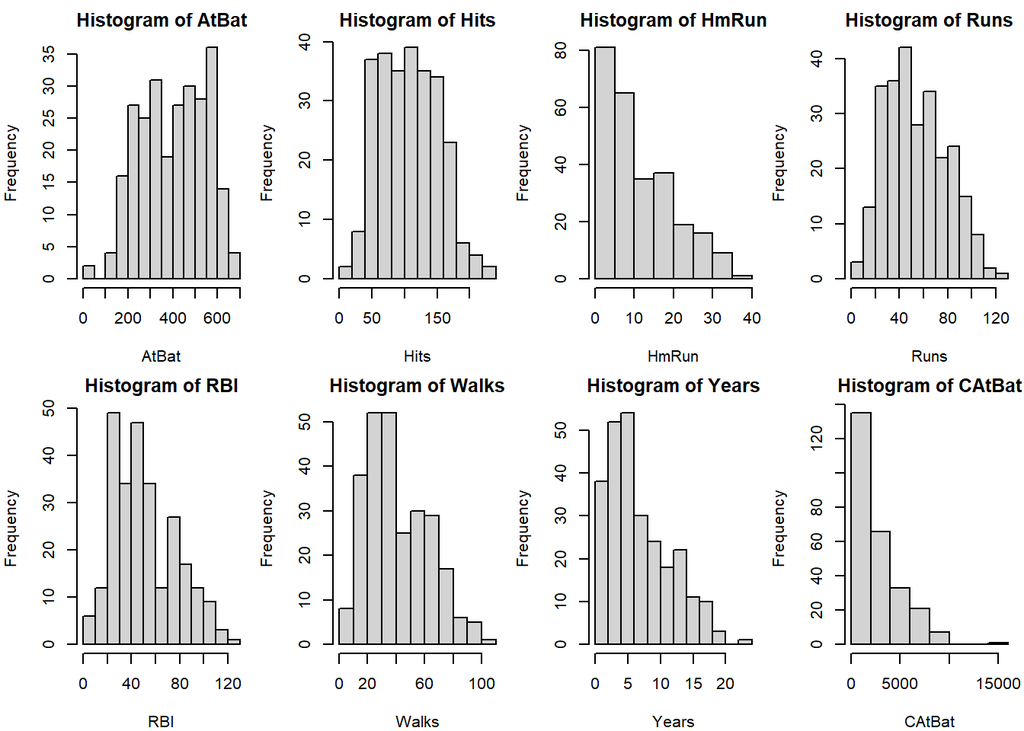

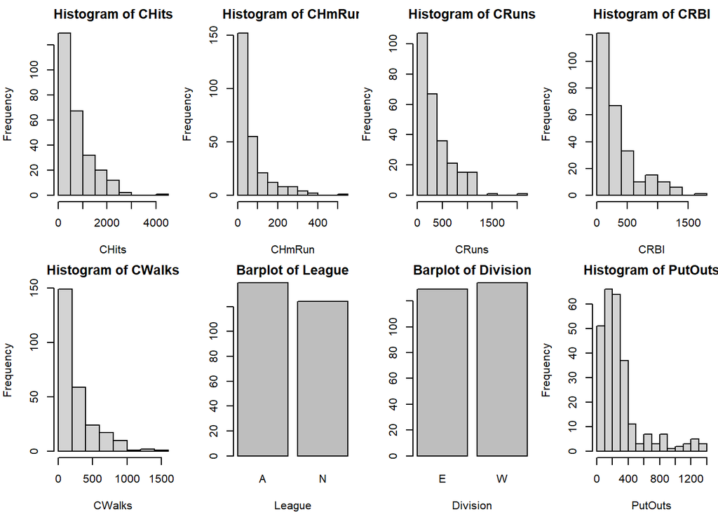

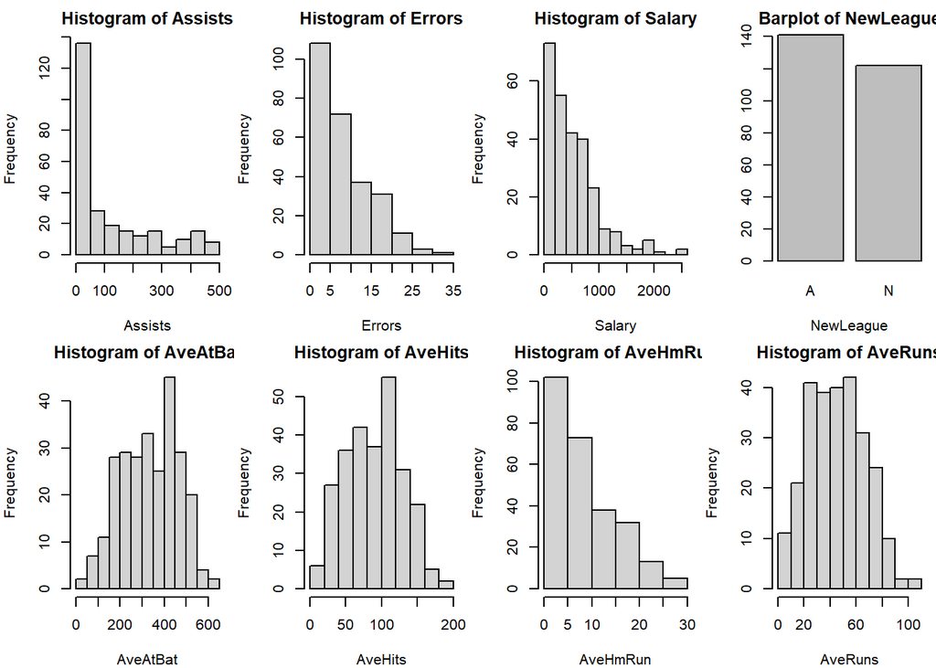

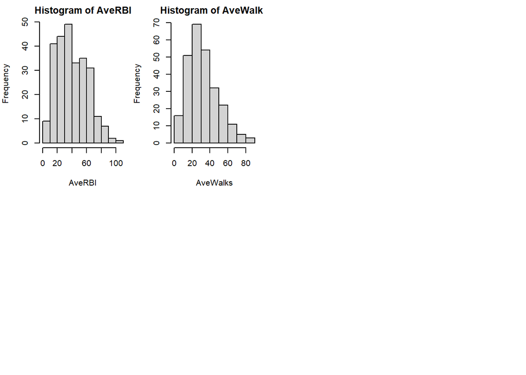

```r
par(mfrow = c(2,4), mar = c(4,4,2,.5))
for (i in c(1:ncol(hitters.noNA.df))) {
  if (typeof(hitters.noNA.df[,i]) == "character"){
    barplot(table(hitters.noNA.df[,i]), xlab = colnames(hitters.noNA.df)[i],
            main = paste("Barplot of", colnames(hitters.noNA.df)[i]))
  } else {
    hist(hitters.noNA.df[,i], xlab = colnames(hitters.noNA.df)[i],
         main = paste("Histogram of", colnames(hitters.noNA.df)[i]))
  }
}
```

7. (2 points) To investigate the association between the Salary and each of the other numeric variables, draw a scatter plot using "Salary" at y-axis, and each of the other numeric variable at x axis, For the scatter plots, you should also add a smooth line to explore the potential pattern. Please also calculate the correlation of each numeric variable and salary

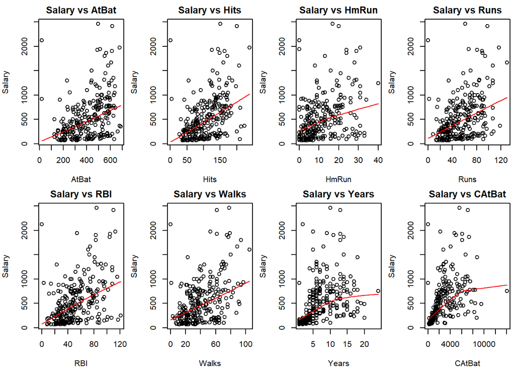

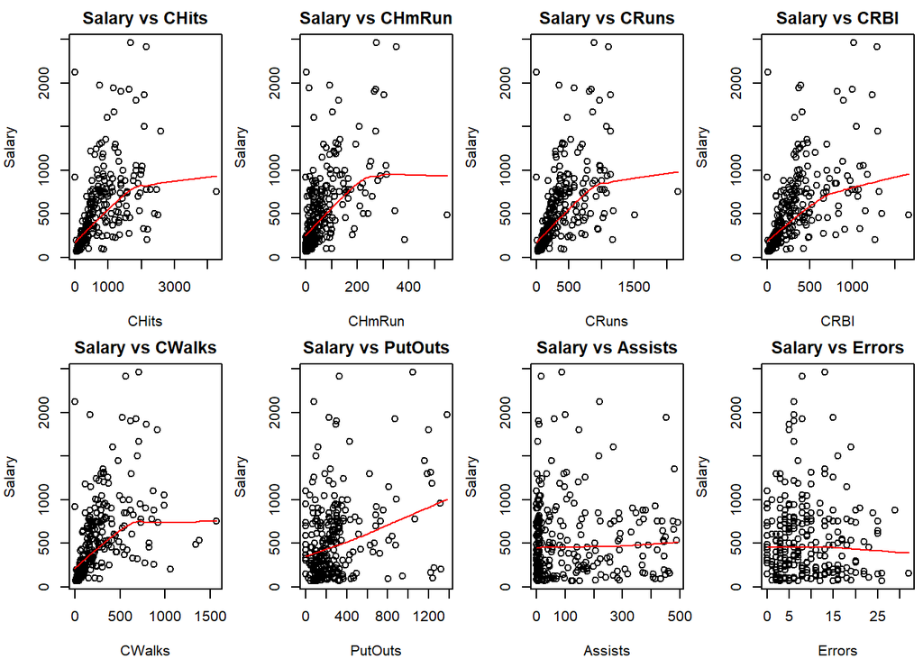

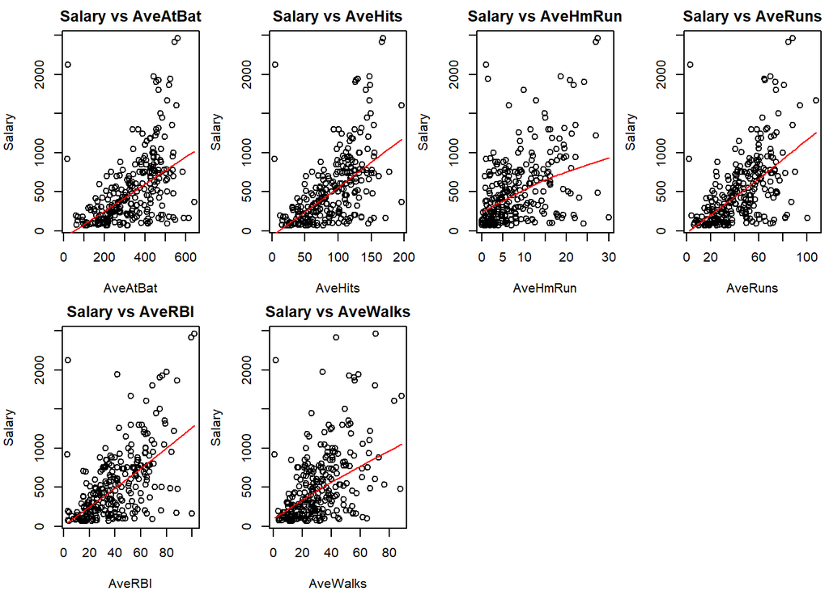

```r
par(mfrow = c(2,4), mar = c(4,4,2,.5))
col.noNA.type = sapply(hitters.noNA.df, typeof)
for (i in which(colnames(hitters.noNA.df) != "Salary" & col.noNA.type != "character")) {
  plot(hitters.noNA.df[,i], hitters.noNA.df$Salary, xlab = colnames(hitters.noNA.df)[i],
      ylab = "Salary", main = paste("Salary vs", colnames(hitters.noNA.df)[i]))
  lines(lowess(hitters.noNA.df[,i], hitters.noNA.df$Salary, f = 1), col = 'red')
}
```

```r
hitters.Sal.cor = cor(hitters.noNA.df$Salary, hitters.noNA.df[,which(colnames(hitters.noNA.df) != "Salary" & col.noNA.type != "character")])
hitters.Sal.cor
```

```
##          AtBat      Hits     HmRun      Runs       RBI     Walks    Years
## [1,] 0.3947709 0.4386747 0.3430281 0.4198586 0.4494571 0.4438673 0.400657
##         CAtBat     CHits    CHmRun     CRuns      CRBI   CWalks   PutOuts
## [1,] 0.5261353 0.5489096 0.5249306 0.5626777 0.5669657 0.489822 0.3004804
##         Assists       Errors  AveAtBat   AveHits  AveHmRun  AveRuns    AveRBI
## [1,] 0.02543614 -0.005400702 0.5049177 0.5585719 0.4413483 0.547637 0.5804059
##       AveWalks
## [1,] 0.4770945
```

8. (1 points) Re-do the analysis for the above question, except that now using log of Salary.

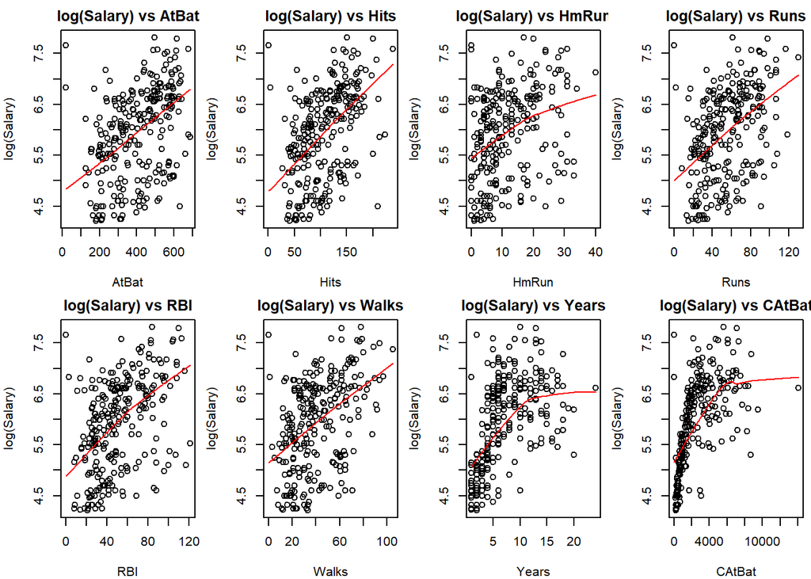

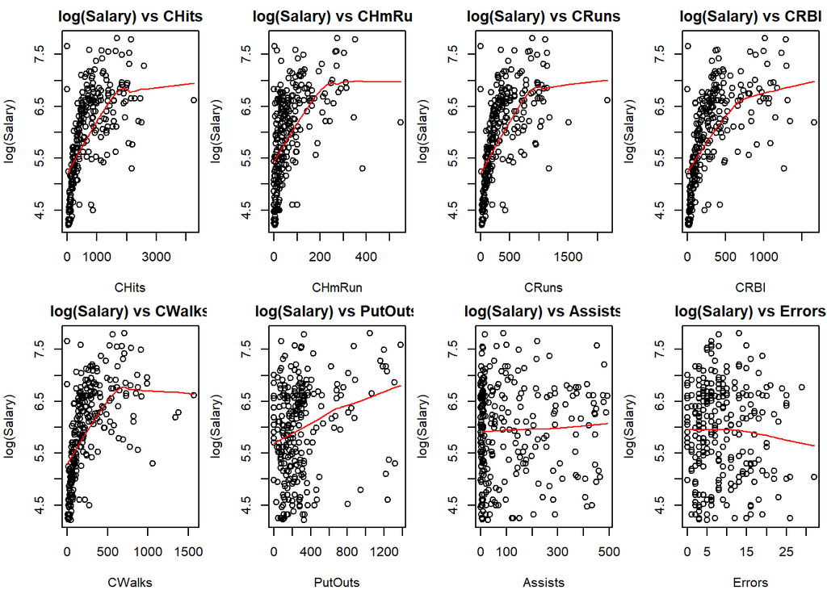

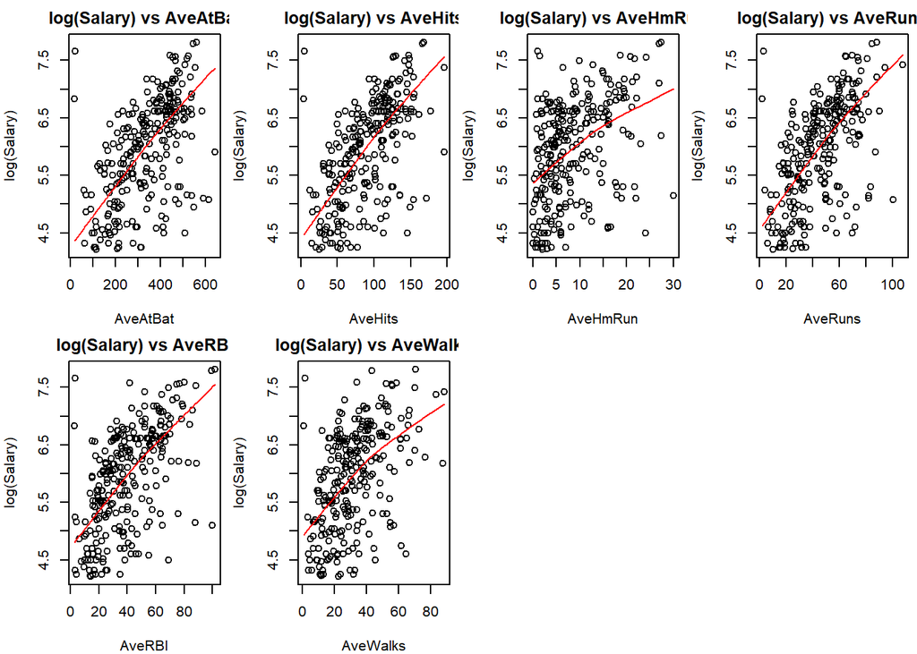

```r
par(mfrow = c(2,4), mar = c(4,4,2,.5))
for (i in which(colnames(hitters.noNA.df) != "Salary" & col.noNA.type != "character")) {
  plot(hitters.noNA.df[,i], log(hitters.noNA.df$Salary), xlab = colnames(hitters.noNA.df)[i],
       ylab = "log(Salary)", main = paste("log(Salary) vs", colnames(hitters.noNA.df)[i]))
  lines(lowess(hitters.noNA.df[,i], log(hitters.noNA.df$Salary), f = 1), col = 'red')
}
```

```r
hitters.noNA.df$LogSalary = log(hitters.noNA.df$Salary)
col.noNA.addLog.type = c(col.noNA.type, "double")
hitters.logSal.cor = cor(hitters.noNA.df$LogSalary, hitters.noNA.df[,which(col.noNA.addLog.type != "character" & !(colnames(hitters.noNA.df) %in% c("Salary", "LogSalary")))])
hitters.logSal.cor
```

```
##          AtBat      Hits     HmRun      Runs       RBI     Walks     Years
## [1,] 0.4149459 0.4495841 0.3398543 0.4255955 0.4441502 0.4324392 0.5373714
##      CAtBat     CHits    CHmRun     CRuns      CRBI    CWalks   PutOuts
## [1,] 0.6108 0.6199411 0.5239427 0.6210893 0.6026713 0.5465807 0.2244826
##         Assists      Errors  AveAtBat   AveHits  AveHmRun   AveRuns    AveRBI
## [1,] 0.04996914 -0.02076464 0.5555027 0.5949571 0.4031806 0.5649174 0.5745779
##       AveWalks
## [1,] 0.4851109
```

```r
hitters.noNA.df$LogSalary = NULL
```

9. (2 points) To investigate the association be a side-by-side box plot of "Salary" using each of the categorical variable as the grouping variable.

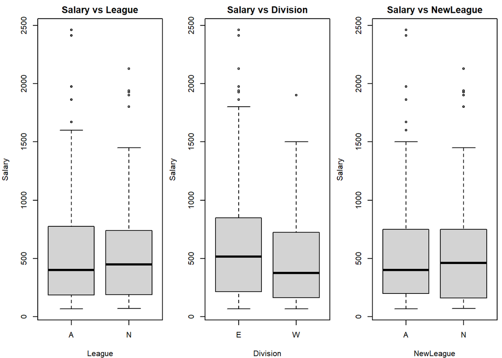

```r
par(mfrow = c(1,3), mar = c(4,4,2,.5))
for (i in which(colnames(hitters.noNA.df) != "Salary" & col.noNA.type == "character")) {
  boxplot(hitters.noNA.df$Salary~factor(hitters.noNA.df[,i]), xlab = colnames(hitters.noNA.df)[i],
          ylab = "Salary", main = paste("Salary vs", colnames(hitters.noNA.df)[i]))

}
```

10. (1 point) Test the difference in the average salary between East and West devision.

```r
t.test(hitters.noNA.df$Salary[hitters.noNA.df$Division=="E"],hitters.noNA.df$Salary[hitters.noNA.df$Division=="W"])
```

```
##
##  Welch Two Sample t-test
##
## data:  hitters.noNA.df$Salary[hitters.noNA.df$Division == "E"] and hitters.noNA.df$Salary[hitters.noNA.df$Division == "W"]
## t = 3.145, df = 218.46, p-value = 0.001892
## alternative hypothesis: true difference in means is not equal to 0
## 95 percent confidence interval:
##   64.73206 282.05692
## sample estimates:
## mean of x mean of y
##  624.2714  450.8769
```

11. (2 points) Compute, using `lm()`, a linear regression model of the log of Salary on Hits,AveHits,Years,Division. Save the results as `hitters.lm`. Using `summary()`, display the coefficients (intercept and slope).

```r
hitters.lm = lm(log(Salary) ~ Hits + AveHits + Years + Division, data = hitters.noNA.df)
summary(hitters.lm)
```

```
##
## Call:
## lm(formula = log(Salary) ~ Hits + AveHits + Years + Division,
##     data = hitters.noNA.df)
##
## Residuals:
##      Min       1Q   Median       3Q      Max
## -2.06341 -0.47372  0.05548  0.41691  3.11182
##
## Coefficients:
##              Estimate Std. Error t value Pr(>|t|)
## (Intercept)  4.356196   0.123795  35.189  < 2e-16 ***
## Hits         0.004868   0.001225   3.975 9.13e-05 ***
## AveHits      0.006158   0.001497   4.113 5.26e-05 ***
## Years        0.081015   0.008955   9.047  < 2e-16 ***
## DivisionW   -0.196409   0.076603  -2.564   0.0109 *
## ---
## Signif. codes:  0 '***' 0.001 '**' 0.01 '*' 0.05 '.' 0.1 ' ' 1
##
## Residual standard error: 0.6183 on 258 degrees of freedom
## Multiple R-squared:  0.5239, Adjusted R-squared:  0.5165
## F-statistic: 70.98 on 4 and 258 DF,  p-value: < 2.2e-16
```

12. (2 points) Plot the diagnostic plots of hitters.lm. Do you think the fit is good?

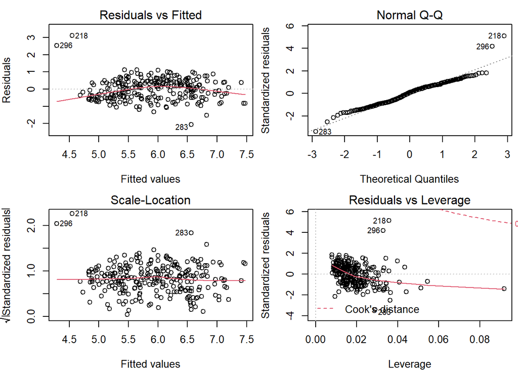

```r
par(mfrow = c(2,2), mar = c(4,4,2,.5))
plot(hitters.lm)
```

Comments: I think generally it is good. Residuals vs Fitted: It appears a small curve pattern, but generally it is randomly scattered, 218 and 296 might be outliers. Normal Q-Q: Most points are along the 45 degree line, although on two tails there are some points far away from the line. Scale-Location plot: No obvious group, only two points (218 and 296) are far from the center. Residuals vs Leverage: All points are in Cook's distance, no potential outliers are found.

13. (1 point)Predict the salary at the original scale for all the players whose salary is missing from the original data.

```r
hitters.NA.df = hitters.df[which(rowSums(is.na(hitters.df)) != 0),]
exp(predict(hitters.lm, newdata = hitters.NA.df))
```

```
##          1         16         19         23         31         33         37
##  175.03100  107.65294  599.89736  112.30808  742.46811  520.86825  187.01076
##         39         40         42         43         45         49         53
##  855.02039  136.10431  692.19850  279.90213  420.12751 1278.97328  113.78929
##         58         65         67         70         72         78         81
##  512.85910   87.78702  165.89104  671.97858  128.88939  252.71397  762.56525
##         84         95         98        102        104        105        106
##  179.08435  264.73918  599.94205  388.15839  417.39090  843.42565  194.97040
##        107        115        126        139        145        151        158
##  172.54450  884.14668  402.65486  255.13899  315.16693  264.10152  253.02884
##        159        161        170        172        174        198        200
##  657.69850  246.54606  208.08313  142.99130  145.41766  122.99131  505.61912
##        204        209        211        226        229        236        247
##  198.20373  198.19554  325.93888  211.81948  485.88801  439.32723  409.74040
##        251        254        255        271        284        293        299
##   74.21466  112.83994  296.92226  148.21149   93.71696  700.34729  196.04512
##        303        306        317
## 1099.81981  845.64811  239.89085
```

Remark: I often use log transformation on a variable if it is always non-negative and right skewed. The problem with transformation in general is that the models built using transformed variables may become hard to interpret. I personally think log transformation is ok in the scenarios when I am using it. But some more strict statisticians may prefer not to, and dislike what I do. Similarly, sometimes I think some other statisticians are using too many different transformations of variables too arbitrarily, and too liberally. What I am trying to say is that even though I have used log transformation many times in this course, please do NOT take it for granted, and please do NOT take any transformation of variables for granted, even standardization (linear transformation: subtracting the mean and then dividing by the standard deviation)

14. (2 points) Linear model can be generalized in many ways. If the response variable does not follow a normal distribution, especially when it is discrete or categorical, you may want to try generalized linear model. When the response variable is binary (0 or 1), you can fit a logistic regression. Fit a logistic regression model, using `glm()` with `family="binomial"`, with the response variable being the indicator that Salary is larger than 750, and the predictor variables being Hits, AveHits, Years, Division. Call the result `hitters.glm`. Note: you can set this up in two different ways: (i) you can manually define a new column (say) salary.high in the `hitters.noNA.df` data frame to be the indicator that the Salary column is larger than 750; or (ii) you can define an indicator variable "on-the-fly" in the call to `glm()` with an appropriate usage of `I()`. Display a summary, reporting the coefficient estimates and standard errors, and associated p-values.

```r
hitters.noNA.df$salary.high = ifelse(hitters.noNA.df$Salary > 750, 1, 0)
hitters.glm = glm(salary.high ~ Hits + AveHits + Years + Division, data = hitters.noNA.df, family = "binomial")
summary(hitters.glm)
```

```
##
## Call:
## glm(formula = salary.high ~ Hits + AveHits + Years + Division,
##     family = "binomial", data = hitters.noNA.df)
##
## Deviance Residuals:
##     Min       1Q   Median       3Q      Max
## -1.7635  -0.6064  -0.3122  -0.1337   3.5424
##
## Coefficients:
##              Estimate Std. Error z value Pr(>|z|)
## (Intercept) -5.767777   0.827102  -6.973 3.09e-12 ***
## Hits         0.012854   0.005392   2.384 0.017131 *
## AveHits      0.022356   0.006942   3.221 0.001279 **
## Years        0.134693   0.039705   3.392 0.000693 ***
## DivisionW   -0.780061   0.354333  -2.201 0.027701 *
## ---
## Signif. codes:  0 '***' 0.001 '**' 0.01 '*' 0.05 '.' 0.1 ' ' 1
##
## (Dispersion parameter for binomial family taken to be 1)
##
##     Null deviance: 287.26  on 262  degrees of freedom
## Residual deviance: 207.86  on 258  degrees of freedom
## AIC: 217.86
##
## Number of Fisher Scoring iterations: 5
```

```r
hitters.noNA.df$salary.high = NULL
```

15. (4 points) Another generalization of the (generalized) linear model is the (generalized) additive modeling (GAM) GAM allows the relationship for certain predictors to be nonlinear, but a smooth function. In this example, we will use it to model Years and Hits, but not AveHits. Recall that in the scatter plot, Years obviously has a nonlinear relationship with Salary (even after log transformation).

Install the `mgcv` package, if you haven't already, and load it into your R session with `library(mgcv)`. Fit a generalized additive model, using `gam()` with `family="gaussian"`, with the response variable being the log of Salary, and the predictor variables being Hits,AveHits,Years, and Division. Also, in the call to `gam()`, allow for Hits,Years to have a nonlinear effect by using `s()`. The variables that are left alone (AveHits and Dvision) will have the default, linear effects. Call the result hitters.gam. Display a summary with `summary()`. How have these predictors change, in terms of their p-value, to what you saw in the linear regression model? Also, plot the fitted effect for each nonlinear predictor, using `plot()`. Comment on the plots---does the fitted effect make sense to you? In particular, is there a strong nonlinearity associated with the effect of Years, and does this make sense? Please also predict the salary of the players who have this information missing in the original dataset.

```r
library(mgcv)
hitters.noNA.df$LogSalary = log(hitters.noNA.df$Salary)
hitters.gam = gam(LogSalary ~ s(Hits) + AveHits + s(Years) + Division, data = hitters.noNA.df, family = "gaussian")
summary(hitters.gam)
```

```
##
## Family: gaussian
## Link function: identity
##
## Formula:
## LogSalary ~ s(Hits) + AveHits + s(Years) + Division
##
## Parametric coefficients:
##              Estimate Std. Error t value Pr(>|t|)
## (Intercept)  5.077213   0.098782  51.398   <2e-16 ***
## AveHits      0.010025   0.001028   9.755   <2e-16 ***
## DivisionW   -0.101108   0.050663  -1.996   0.0471 *
## ---
## Signif. codes:  0 '***' 0.001 '**' 0.01 '*' 0.05 '.' 0.1 ' ' 1
##
## Approximate significance of smooth terms:
##            edf Ref.df     F p-value
## s(Hits)  8.513  8.933 16.40  <2e-16 ***
## s(Years) 5.377  6.512 67.99  <2e-16 ***
## ---
## Signif. codes:  0 '***' 0.001 '**' 0.01 '*' 0.05 '.' 0.1 ' ' 1
##
## R-sq.(adj) =  0.797   Deviance explained = 80.9%
## GCV = 0.17175  Scale est. = 0.16072   n = 263
```

In terms of p-value, they become extremely lower than the previous p-value from linear regression (Except for the predictor Deivision).

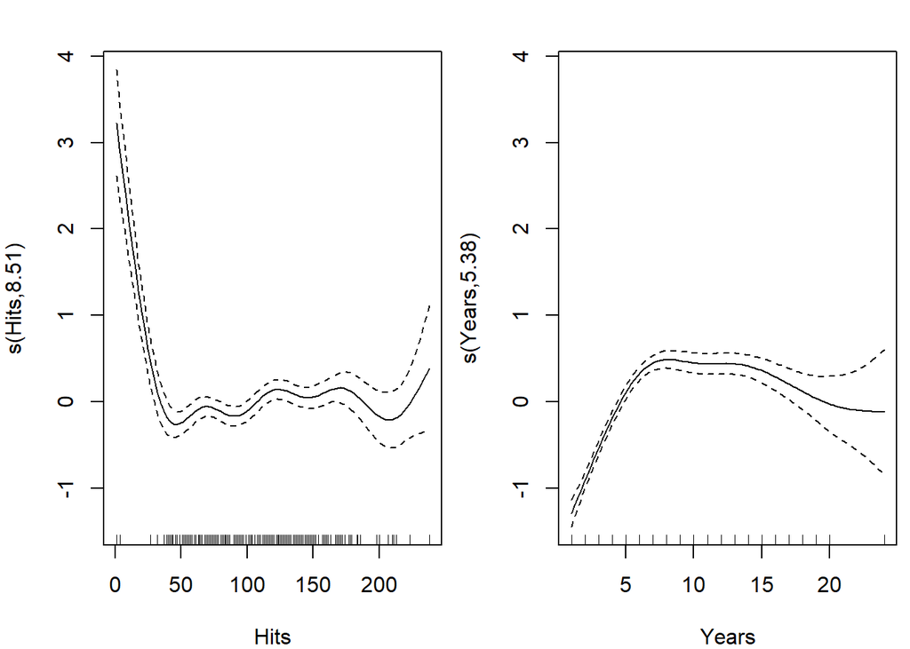

```r
par(mfrow = c(1,2), mar = c(4,4,2,.5))
plot(hitters.gam)
```

According to the plot of the fitted effect of years, there are some nonlinear effects, we could see the curve on two sides. However, about the plot of the fitted effect of Hits, although there are curves on two sides, the middle of the line are almost flat, and a lot of observations are concentrated there. There are only few observations on two sides, they may cause those boundary variations. Generally speaking, further studies are required for this case.

```r
exp(predict(hitters.gam, newdata = hitters.NA.df))
```

```
##          1         16         19         23         31         33         37
##   80.01468   81.75436  733.27942 1790.48741  453.30331  745.24618  226.54855
##         39         40         42         43         45         49         53
##  515.91723   65.94912  390.62843  425.87133  539.34349  862.27252 1668.92815
##         58         65         67         70         72         78         81
##  454.97117 1834.99055  178.17486  751.52193  132.89160  331.36578  586.60231
##         84         95         98        102        104        105        106
##  237.30267  453.35230  589.57194  265.34063  434.45085  954.90707  298.24942
##        107        115        126        139        145        151        158
##  115.34911  488.07130  443.16408  348.17747  437.60285  292.76488  216.09352
##        159        161        170        172        174        198        200
##  516.78490  219.83443  211.73657   70.97263  120.09124   62.61753  674.94359
##        204        209        211        226        229        236        247
##  189.83145  196.39315  490.63293  250.06604  556.98946  604.88791  660.53312
##        251        254        255        271        284        293        299
##  580.65163   47.86440  519.22067   77.98733 1466.85519  516.22583  220.96682
##        303        306        317
##  336.52284  861.62275  301.13732
```